# Bayesian data analysis & cognitive modeling

## At a glance

- BDA is about what we *should* believe given:
  - some observable data, and
  - our model of how this data was generated.
- Our best friend will be Bayes rule: \[\underbrace{P(\theta \, | \, D)}_{posterior} \propto \underbrace{P(\theta)}_{prior} \times \underbrace{P(D \, | \, \theta)}_{likelihood}\]
- If \(P(\theta \, | \, D)\) is hard to compute, we resort to magic some clever stuff.

## Example: coin flips

- \(\theta \in [0;1]\) is the bias of a coin:
  - if we throw a coin, the outcome will be heads with probability \(\theta\)
- we have no clue about \(\theta\) at the outset:
  - *a priori* we consider every possible value of \(\theta\) equally likely
- we observe that of 24 flips 7 were heads
- what shall we believe about \(\theta\) now?

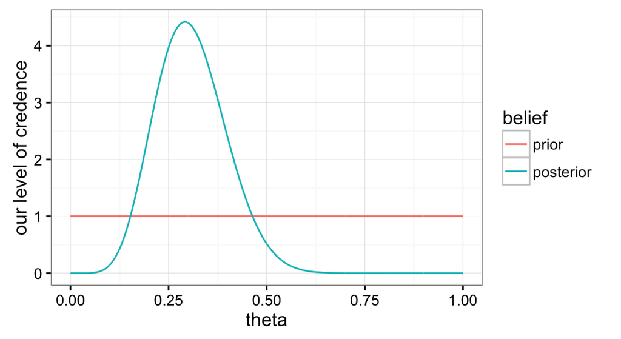

## "Classic statistics"

- null hypothesis significance testing (NHST)
  - e.g., is the coin fair (\(\theta = 0.5\))
  - [tyranny of the discontinuous mind](http://www.newstatesman.com/blogs/the-staggers/2011/12/issue-essay-line-dawkins)
- relies on sampling distributions & \(p\)-values
  - standard "tests" can have rigid built-in assumptions
  - implicitly rely on experimenter's intentions
- looks at point estimates only
- bag of magic tricks

[figure not shown]

## Any thoughts?

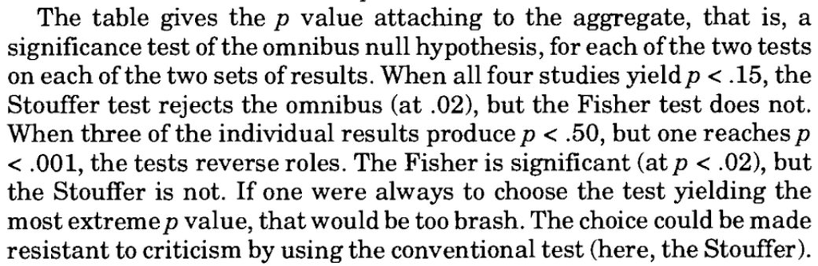

from Abelson (1995) "Statistics as a Principled Argument"; quote tweeted by Richard D. Morey, April 24 2017

## Pros & Cons of BDA

### Pro

- well-founded & totally general
- easily extensible / customizable
- more informative / insightful
- stimulates view: "models as tools"

[figure not shown]

### Con

- less ready-made, more hands-on
- not yet fully digested by community
- possibly computationally complex
- requires thinking (wait, that's a pro!)

[figure not shown]

## 3 times Bayes

1. Bayesian statistics
   - Bayesian alternatives to "classic" statistical analyses (e.g., Kruschke 2015)
2. Bayesian cognitive modeling
   - custom models of the data-generating process (e.g., Lee & Wagenmakers 2014)
3. Bayesian models of cognition
   - model (human) cognition as Bayesian inference (e.g., Goodman & Tenenbaum [2016](https://probmods.org))

## Goals of this course

- to understand basic ideas of BDA (contrast with NHST)
- to see how BDA blends seamlessly into cognitive modeling
- to be able to read current literature on BDA
- to implement and evaluate Bayesian analyses

## Credits

for 6 credits you must …

- hand in all homework sets (4 or 5), and
- finish with a final project, e.g.:
  - take home exam (enough for a Proseminar Schein)
  - a literature survey (enough for a Proseminar Schein)
  - an analysis of your own data set
  - a replication/extension of some other analysis
  - write a discussion paper (e.g., philosophy of BDA)

grade will be a (non-arbitrary) function of homework grades and final project

## Etiquette

- slides are not self-explanatory -> you must attend class
- one-minded attention during class -> no social media, news or whatever
- come prepared, read around, think along, ask questions
- recap lesson later the same day:
  - rethink
  - reread
  - take notes
  - prepare questions
- nobody is master; all are fallible; knowledge gain is community work

## Preparation for next class

- check the [website](https://michael-franke.github.io/BDACM_2017/)
- read the notes on [materials](https://michael-franke.github.io/BDACM_2017/notes/01_github.html), [software](https://michael-franke.github.io/BDACM_2017/notes/02_software.html), and [literature](https://michael-franke.github.io/BDACM_2017/notes/03_literature.html)
- install R & RStudio -> play around!
- browse, read or devour [R for Data Science](http://r4ds.had.co.nz)